# Dimensionality reduction techniques

## Perform principal component analysis (PCA) – Non standarized data

```r
# perform principal component analysis
pca_human_new <- prcomp(human_new)
summary(pca_human_new)
```

```
## Importance of components:
##                              PC1      PC2   PC3   PC4   PC5   PC6   PC7    PC8
## Standard deviation     1.854e+04 186.1920 25.97 19.25 11.42 3.723 1.431 0.1649
## Proportion of Variance 9.999e-01   0.0001  0.00  0.00  0.00 0.000 0.000 0.0000
## Cumulative Proportion  9.999e-01   1.0000  1.00  1.00  1.00 1.000 1.000 1.0000
```

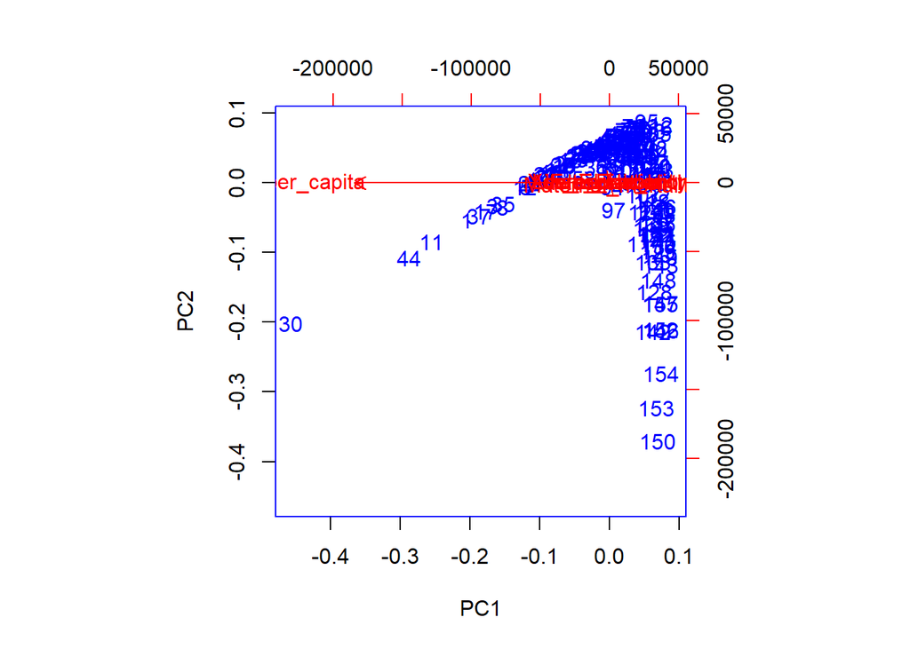

Figure 1: CPA – Non standarized data

```r
# draw a biplot of the principal component
biplot(pca_human_new, choices = 1:2, col = c("blue", "red"))
```

## Perform principal component analysis (PCA) – Standarized data

```r
# standardize the variables
human_std <- scale(human_new)

# perform principal component analysis
pca_human_std <- prcomp(human_std)
summary(pca_human_std)
```

```
## Importance of components:
##                           PC1    PC2     PC3     PC4     PC5     PC6     PC7
## Standard deviation     2.1194 1.1478 0.89070 0.73763 0.55201 0.48552 0.44894
## Proportion of Variance 0.5615 0.1647 0.09917 0.06801 0.03809 0.02947 0.02519
## Cumulative Proportion  0.5615 0.7261 0.82532 0.89333 0.93142 0.96089 0.98608
##                            PC8
## Standard deviation     0.33372
## Proportion of Variance 0.01392
## Cumulative Proportion  1.00000
```

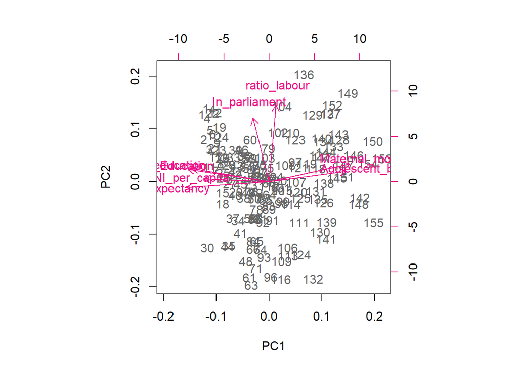

Figure 2: CPA – Standarized data

```r
# draw a biplot of the principal component
biplot(pca_human_std, choices = 1:2, col = c("grey40", "deeppink2"))
```

**Interpretations:**

- **With and without standardizing, are the results different?** Yes, with and without standardizing, results are very much different.
- **How and Why?** In Figure 1 – PCA with no-standardized data, we can not really grasp the variability captured by the principal components. This is because PCA is sensitive to the relative scaling of the original features and assumes that features with larger variance are more important than features with smaller variance. That is probably the reason why the GNI_per_capita has a larger arrow. Also, 99% of variation explained by 1 PCA component.
- Figure 2, on the other hand, displays how Standardization of the features before PCA is a crucial step. The PCA decomposes data into a product of smaller components and reveals the most important features. 98% of variation explained by 7 PCA components, as presented in the Cumulative Proportion. The 1st principal component which captures the maximum amount of variance from the features in the original data counts for 56%.